# Simple Linear Regression

## What I'm Doing

I implemented a simple linear regression with scikit‑learn, using engine size to predict **CO₂ emissions** from Canadian vehicle fuel data. I split the dataset 80/20 for training and testing, then evaluated the model with MAE, MSE, and R².

## 1. Setting Up

I start by importing the essential libraries for data manipulation, numpy, and visualization.

```
%pip install matplotlib pandas numpy scikit-learn
import matplotlib.pyplot as plt
import pandas as pd
import pylab as pl
import numpy as np
%matplotlib inline
```

download dataset from IBM Object Storage using `!curl -o` (Linux: `!wget -O`)

```
!curl -o FuelConsumption.csv https://cf-courses-data.s3.us.cloud-object-storage.appdomain.cloud/IBMDeveloperSkillsNetwork-ML0101EN-SkillsNetwork/labs/Module%202/data/FuelConsumptionCo2.csv
```

```
  % Total    % Received % Xferd  Average Speed   Time    Time     Time  Current
                                 Dload  Upload   Total   Spent    Left  Speed

  0     0    0     0    0     0      0      0 --:--:-- --:--:-- --:--:--     0
  0     0    0     0    0     0      0      0 --:--:-- --:--:-- --:--:--     0
  0     0    0     0    0     0      0      0 --:--:--  0:00:01 --:--:--     0
100 72629  100 72629    0     0  31942      0  0:00:02  0:00:02 --:--:-- 31981
```

## 2. Getting to Know the Dataset

Then I load and inspect the first few rows.

```
df = pd.read_csv("FuelConsumption.csv")
df.head()
```

|  | MODELYEAR | MAKE | MODEL | VEHICLECLASS | ENGINESIZE | CYLINDERS | TRANSMISSION | FUELTYPE | FUELCONSUMPTION_CITY | FUELCONSUMPTION_HWY | FUELCONSUMPTION_COMB | FUELCONSUMPTION_COMB_MPG | CO2EMISSIONS |
| --- | --- | --- | --- | --- | --- | --- | --- | --- | --- | --- | --- | --- | --- |
| 0 | 2014 | ACURA | ILX | COMPACT | 2.0 | 4 | AS5 | Z | 9.9 | 6.7 | 8.5 | 33 | 196 |
| 1 | 2014 | ACURA | ILX | COMPACT | 2.4 | 4 | M6 | Z | 11.2 | 7.7 | 9.6 | 29 | 221 |
| 2 | 2014 | ACURA | ILX HYBRID | COMPACT | 1.5 | 4 | AV7 | Z | 6.0 | 5.8 | 5.9 | 48 | 136 |
| 3 | 2014 | ACURA | MDX 4WD | SUV - SMALL | 3.5 | 6 | AS6 | Z | 12.7 | 9.1 | 11.1 | 25 | 255 |
| 4 | 2014 | ACURA | RDX AWD | SUV - SMALL | 3.5 | 6 | AS6 | Z | 12.1 | 8.7 | 10.6 | 27 | 244 |

**`Result:`** The dataset contains model year, make, model, vehicle class, engine specs, fuel consumption ratings, and the target - CO₂ emissions in g/km. Dataset source

A quick statistical summary of each numerical column.

```
df.describe()
```

|  | MODELYEAR | ENGINESIZE | CYLINDERS | FUELCONSUMPTION_CITY | FUELCONSUMPTION_HWY | FUELCONSUMPTION_COMB | FUELCONSUMPTION_COMB_MPG | CO2EMISSIONS |
| --- | --- | --- | --- | --- | --- | --- | --- | --- |
| count | 1067.0 | 1067.000000 | 1067.000000 | 1067.000000 | 1067.000000 | 1067.000000 | 1067.000000 | 1067.000000 |
| mean | 2014.0 | 3.346298 | 5.794752 | 13.296532 | 9.474602 | 11.580881 | 26.441425 | 256.228679 |
| std | 0.0 | 1.415895 | 1.797447 | 4.101253 | 2.794510 | 3.485595 | 7.468702 | 63.372304 |
| min | 2014.0 | 1.000000 | 3.000000 | 4.600000 | 4.900000 | 4.700000 | 11.000000 | 108.000000 |
| 25% | 2014.0 | 2.000000 | 4.000000 | 10.250000 | 7.500000 | 9.000000 | 21.000000 | 207.000000 |
| 50% | 2014.0 | 3.400000 | 6.000000 | 12.600000 | 8.800000 | 10.900000 | 26.000000 | 251.000000 |
| 75% | 2014.0 | 4.300000 | 8.000000 | 15.550000 | 10.850000 | 13.350000 | 31.000000 | 294.000000 |
| max | 2014.0 | 8.400000 | 12.000000 | 30.200000 | 20.500000 | 25.800000 | 60.000000 | 488.000000 |

## 3. Exploring the Data

I narrow my focus to the four most relevant features for this regression task.

```
cdf = df[['ENGINESIZE','CYLINDERS','FUELCONSUMPTION_COMB','CO2EMISSIONS']]
cdf.head(9)
```

|  | ENGINESIZE | CYLINDERS | FUELCONSUMPTION_COMB | CO2EMISSIONS |
| --- | --- | --- | --- | --- |
| 0 | 2.0 | 4 | 8.5 | 196 |
| 1 | 2.4 | 4 | 9.6 | 221 |
| 2 | 1.5 | 4 | 5.9 | 136 |
| 3 | 3.5 | 6 | 11.1 | 255 |
| 4 | 3.5 | 6 | 10.6 | 244 |
| 5 | 3.5 | 6 | 10.0 | 230 |
| 6 | 3.5 | 6 | 10.1 | 232 |
| 7 | 3.7 | 6 | 11.1 | 255 |
| 8 | 3.7 | 6 | 11.6 | 267 |

Histograms give a quick sense of how each feature is distributed.

```
viz = cdf[['CYLINDERS','ENGINESIZE','CO2EMISSIONS','FUELCONSUMPTION_COMB']]
viz.hist()
plt.show()
```

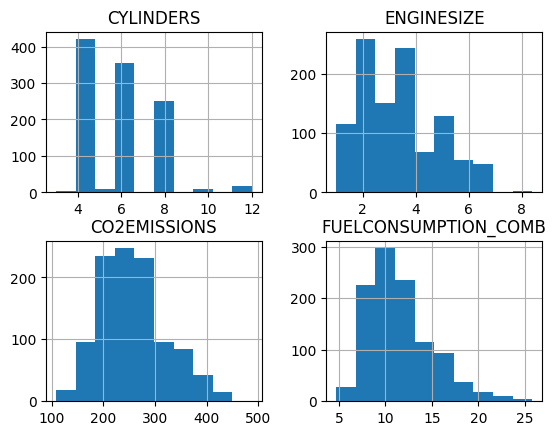

**`Result:`** Four histograms display. Engine size clusters around 2.0–4.0 L, cylinders peak at 4, 6, and 8 combined fuel consumption is right-skewed, and CO₂ emissions form a roughly bell-shaped curve centered near 250 g/km.

Now I check the relationship between each feature and the target variable using scatter plots **to predict emissions**.

```
plt.scatter(cdf.FUELCONSUMPTION_COMB, cdf.CO2EMISSIONS, color='blue')
plt.xlabel("FUELCONSUMPTION_COMB")
plt.ylabel("Emission")
plt.show()
```

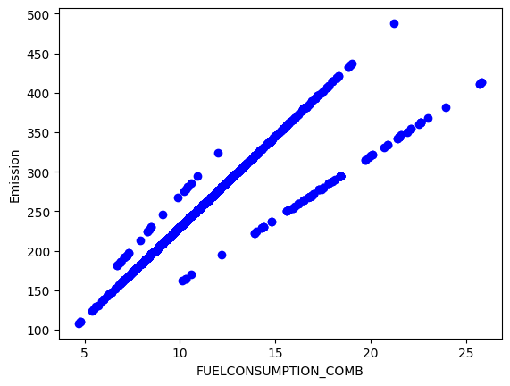

**`Result:`** A strong **positive linear relationship** - as fuel consumption increases, CO₂ emissions rise proportionally.

```
plt.scatter(cdf.ENGINESIZE, cdf.CO2EMISSIONS, color='blue')
plt.xlabel("Engine size")
plt.ylabel("Emission")
plt.show()
```

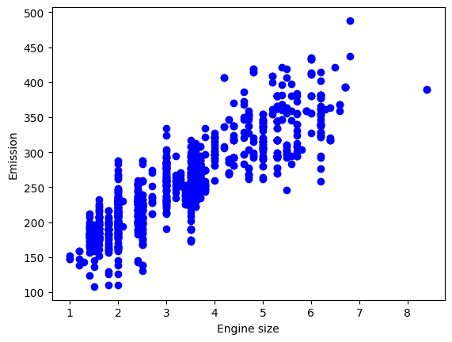

**`Result:`** Another positive trend, though with more scatter. **Larger engines generally produce more CO₂**, but the **relationship is noisier** than fuel consumption.

### **Exercise**: Cylinders vs. Emission

Let's visualize how cylinder count correlates with CO₂ emissions.

```
plt.scatter(cdf.CYLINDERS, cdf.CO2EMISSIONS, color='blue')
plt.xlabel("Cylinders")
plt.ylabel("Emission")
plt.show()
```

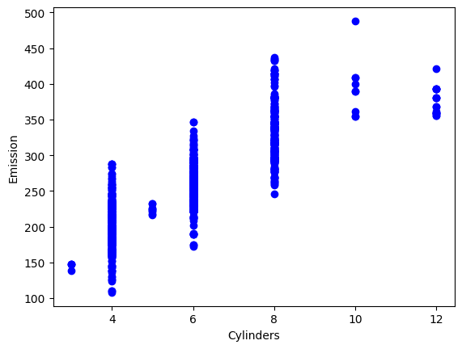

**`Result:`** A clear upward trend - vehicles with more cylinders emit more CO₂. The data clusters at specific cylinder counts (4, 6, 8, etc.), making this a reasonable but coarser predictor than engine size or fuel consumption.

## 4. Train/Test Split

I split the data so the model trains on 80% of observations and tests on the remaining 20%. This ensures I evaluate performance on data the model has never seen by creating a mask to select random rows using **np.random.rand()** function:

```
msk = np.random.rand(len(df)) < 0.8
train = cdf[msk]
test = cdf[~msk]
```

Let's visualize the training subset.

```
plt.scatter(train.ENGINESIZE, train.CO2EMISSIONS, color='blue')
plt.xlabel("Engine size")
plt.ylabel("Emission")
plt.show()
```

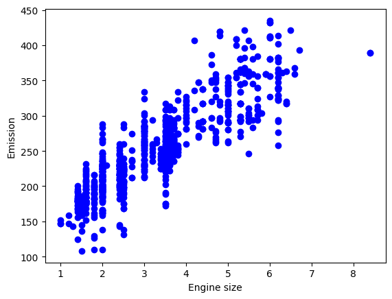

**`Result:`** The training data preserves the same positive trend observed in the full dataset.

## 5. Building the Simple Linear Regression Model

I use scikit-learn's `LinearRegression` to fit a line through the training data, minimizing the residual sum of squares.

```
from sklearn import linear_model

regr = linear_model.LinearRegression()
train_x = np.asanyarray(train[['ENGINESIZE']])
train_y = np.asanyarray(train[['CO2EMISSIONS']])
regr.fit(train_x, train_y)

print('Coefficients: ', regr.coef_)
print('Intercept: ', regr.intercept_)
```

```
Coefficients:  [[38.41986307]]
Intercept:  [127.24947105]
```

The fitted line is:

$$ \text{CO2 Emissions} = 38.42 \times \text{Engine Size} + 127.25 $$

Plotting the regression line over the training data shows how well it captures the trend.

```
plt.scatter(train.ENGINESIZE, train.CO2EMISSIONS, color='blue')
plt.plot(train_x, regr.coef_[0][0]*train_x + regr.intercept_[0], '-r')
plt.xlabel("Engine size")
plt.ylabel("Emission")
plt.show()
```

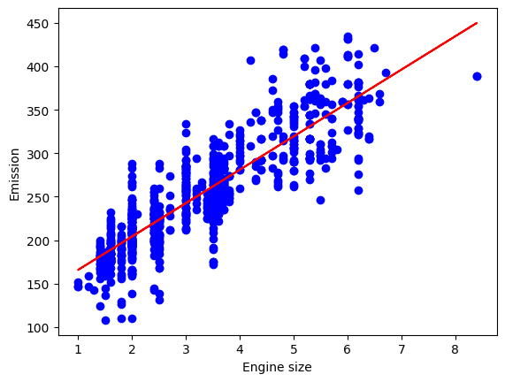

**`Result:`** The red regression line cuts through the scatter, **rising steadily with engine size**. While some variance remains (points spread around the line), the overall linear trend is clear.

## 6. Evaluating the Model

I test the model on the held-out 20% and compute three standard metrics.

```
from sklearn.metrics import r2_score

test_x = np.asanyarray(test[['ENGINESIZE']])
test_y = np.asanyarray(test[['CO2EMISSIONS']])
test_y_ = regr.predict(test_x)

print("Mean absolute error: %.2f" % np.mean(np.absolute(test_y_ - test_y)))
print("Residual sum of squares (MSE): %.2f" % np.mean((test_y_ - test_y) ** 2))
print("R2-score: %.2f" % r2_score(test_y, test_y_))
```

```
Mean absolute error: 24.80
Residual sum of squares (MSE): 1034.49
R2-score: 0.77
```

- **MAE (24.80 g/km):** On average, the model's predictions are off by about 25 g/km.
- **MSE (1034.49):** Squared errors penalize larger deviations.
- **R² (0.77):** **Engine size** explains 77% of the variance in CO₂ emissions - a solid fit for a single feature. (best fit is **1.0**)

## 7. Exercise: Using **Fuel Consumption** as a Feature

Now I repeat the entire workflow using **FUELCONSUMPTION_COMB** as the predictor instead of engine size. This lets me compare which single feature performs better.

**Step 1 - Prepare the training and testing data:**

```
train_x = train[["FUELCONSUMPTION_COMB"]]
test_x = test[["FUELCONSUMPTION_COMB"]]
```

Lets see what the evaluation metrics are if we trained a regression model using the `FUELCONSUMPTION_COMB` feature.

Start by selecting `FUELCONSUMPTION_COMB` as the train_x data from the `train` dataframe, then select `FUELCONSUMPTION_COMB` as the test_x data from the `test` dataframe

**Step 2 - Train the model:**

```
regr = linear_model.LinearRegression()
regr.fit(train_x, train_y)
```

```
LinearRegression()
```

**Step 3 - Make predictions:**

```
predictions = regr.predict(test_x)
```

**Step 4 - Evaluate:**

```
print("Mean Absolute Error: %.2f" % np.mean(np.absolute(predictions - test_y)))
print("Mean Squared Error: %.2f" % np.mean((predictions - test_y) ** 2))
print("R2-score: %.2f" % r2_score(test_y, predictions))
```

```
Mean Absolute Error: 22.15
Mean Squared Error: 873.98
R2-score: 0.80
```